# Graphiques avec ggplot2

Mardi 25 mai 2021

## Avant toutes choses

Nous aurons besoin du package `ggplot2` :

- Vérifier que le package `ggplot2` est bien installé
- Si non, l’installer, puis le charger

```r
library(ggplot2)
```

Nous allons également avoir besoin des données fruits :

```r
data("fruits", package = "tidyViz")
```

## Bien choisir sa représentation graphique

[figure not shown]

From Data to Viz : https://www.data-to-viz.com/

## Un échantillon de ce qu’il est possible de faire avec ggplot2

[figure not shown]

## Diagramme en bâtons

## Rappel : la fonction barplot

La fonction de base pour les diagrammes en bâtons est `barplot` :

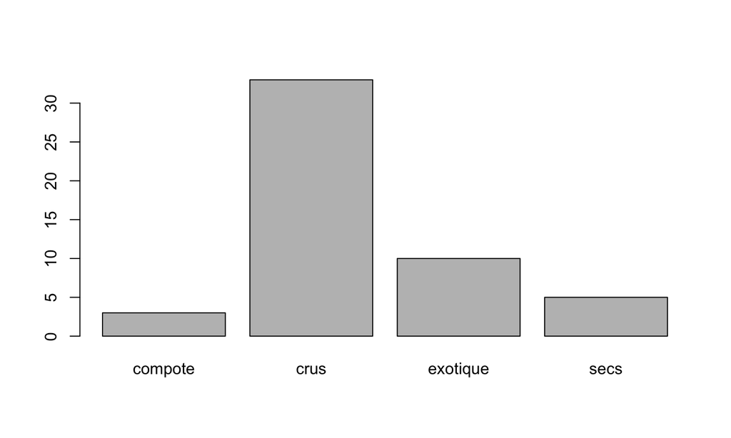

```r
barplot(table(fruits$groupe))
```

Avec des couleurs :

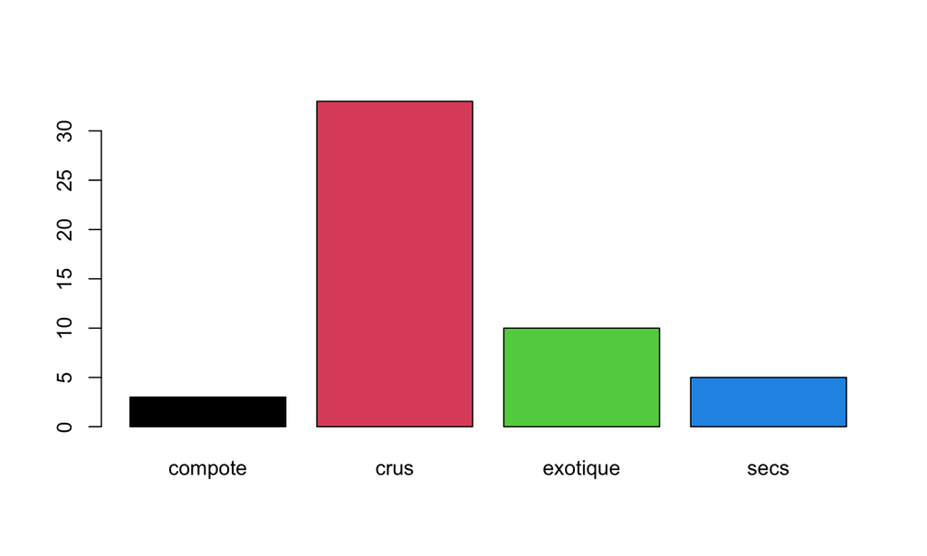

```r
barplot(table(fruits$groupe), col = 1:4)
```

## La fonction geom_bar

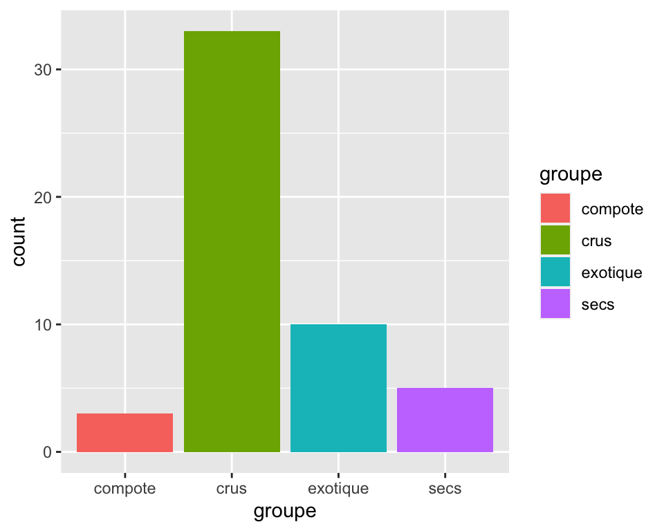

```r
ggplot(data = fruits, aes(x = groupe, fill = groupe)) +
  geom_bar()
```

STOP !

## Décomposition de la commande

- `ggplot` : création d’un canevas vide dans on va dessiner le(s) graphe(s)
- `aes` : déclaration des paramètres esthétiques du graphes (position horizontale, verticale, couleur épaisseur, forme, transparence etc…)
- `geom_bar` : utilisation d’une géométrie

## Les données

[figure not shown]

## Les paramètres esthétiques

[figure not shown]

## Les géométries

[figure not shown]

## L’image à retenir

[figure not shown]

## [G]rammar of [G]raphics

[figure not shown]

## Implémentation dans ggplot2

[output not shown]

## A vous !

Comment corriger la commande suivante pour obtenir le graphe à droite ?

```r
 ggplot(***,
     aes(***,
     fill = Sucres > 10)) +
   geom_***()
```

[figure not shown]

## Un peu d’histoire

- Il y a eu un `ggplot`“1” (voir [ici](https://github.com/hadley/ggplot1))
- Développement commencé en 2005
- Hadley Wickham (*Chief Scientist at RStudio* + *Adjunct Professor of Statistics*)
- D’excellents cours, parfois avec sa soeur Charlotte

[figure not shown]

Hadley Wickham

## Quelques géométries

Nous allons voir ensemble quelques géométries particulières qui permettent de créer des graphes classiques.

| `geom_bar` | Diagramme en bâtons sur des données non-agrégées |
| --- | --- |
| `geom_col` | Diagramme en bâtons (encore) sur des comptages existants |
| `geom_histogram` | Histogramme d’une variable quantitative |
| `geom_boxplot` | Diagramme de Tukey aka “boîte à moustache” aka *boxplot* |
| `geom_violin` | Diagramme en “violons” |
| `geom_point` | Nuage de points créé à partir de deux variables quantitatives |
| `geom_line` | Ligne tracée à partir de deux variables quantitatives |

## Diagrammes en bâtons

## Avec geom_bar

On a déjà vu comment faire :

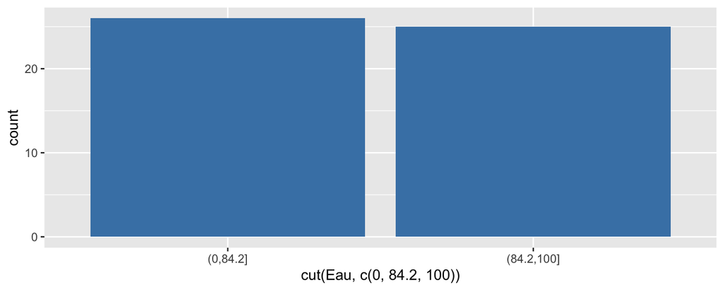

```r
ggplot(fruits, aes(cut(Eau, c(0, 84.2, 100)))) +
  geom_bar(fill = "steelblue")
```

## Avec geom_col

S’utilise **quand on dispose déjà** de comptages.

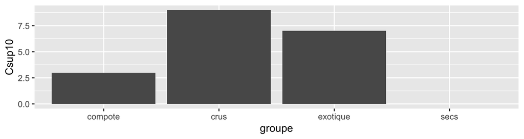

```r
dat.count <- fruits %>%
  group_by(groupe) %>%
  summarize(Csup10 = sum(VitamineC >= 10))

ggplot(data = dat.count, aes(x = groupe, y = Csup10)) +
  geom_col()
```

## A vous !

Comment modifier les deux commandes précédentes pour faire un diagramme en bâtons montrant des pourcentages plutôt que des comptages bruts ?

(PS : il y a plus d’une solution possible)

## Histogrammes

## Histogramme ou diagramme en bâtons ?

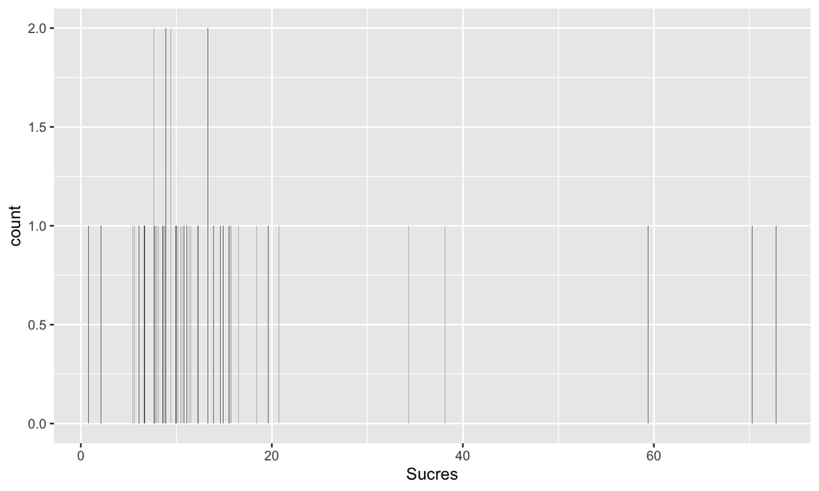

```r
ggplot(fruits, aes(Sucres)) +
  geom_bar()
```

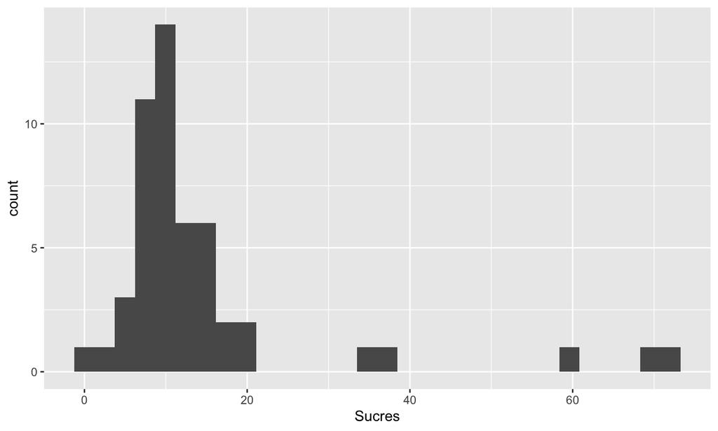

```r
ggplot(fruits, aes(Sucres)) +
  geom_histogram()
```

## Histogramme ou diagramme en bâtons ?

### Diagramme en bâtons

Représente des comptages de :

- variables nominales
- variables ordinales
- variables discrètes

### Histogramme

Représente des comptages ou des densités de :

- variables continues
- variables discrètes

Pour ce genre de graphe, il est important de choisir les intervalles sur lesquels les données seront énumérées.

## L’histogramme par défaut

- Axe des \(y\) : les comptages de l’intervalle donné
- Axe des \(x\) :
  - des intervalles de même amplitude,
  - trente intervalles,
  - pas de séparation visuelle entre les intervalles (sauf ceux qui sont vides)
  - des *rectangles* gris foncé
  - un *message*

[figure not shown]

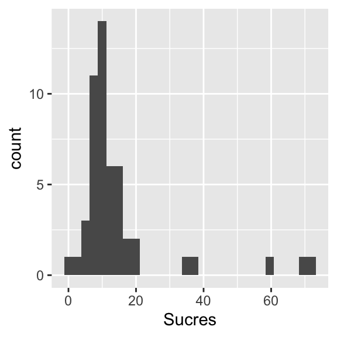

```r
ggplot(fruits, aes(Sucres)) +
  geom_histogram()
```

## Exercice qui n’a (presque) rien à voir!

Dans un document R Markdown, comment faire pour ne pas afficher le message dans votre rapport ?

*… il y a plusieurs solutions possibles…*

## Modification des intervalles

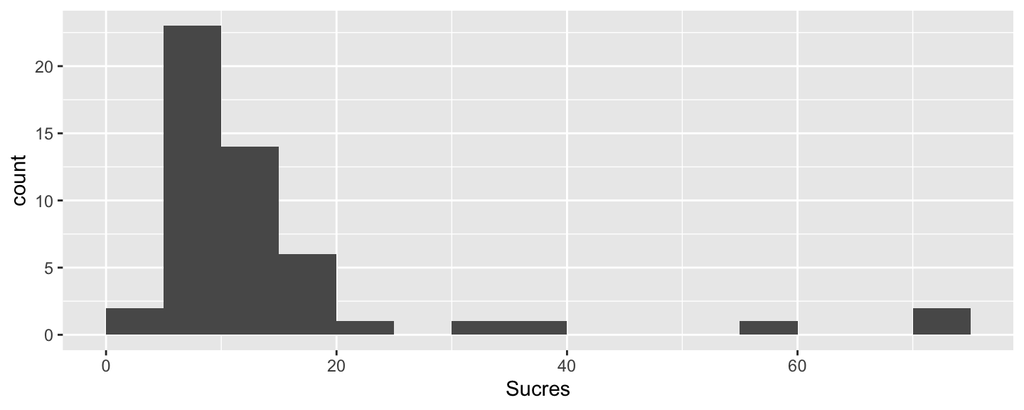

```r
ggplot(fruits, aes(Sucres)) +
  geom_histogram(breaks = seq(0, 75, 5))
```

## Modification de la couleur

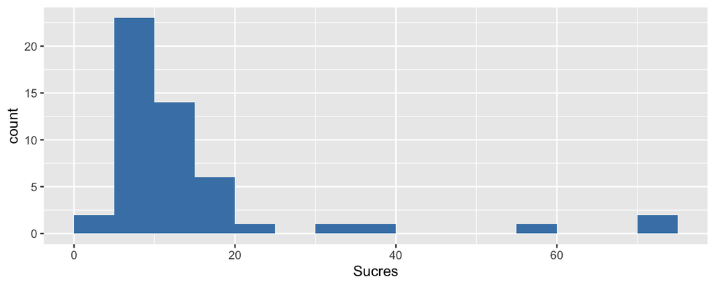

```r
ggplot(fruits, aes(Sucres)) +
  geom_histogram(breaks = seq(0, 75, 5),
                 fill = "steelblue")
```

## Modification de la couleur

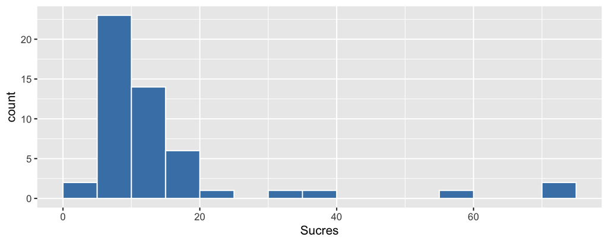

```r
ggplot(fruits, aes(Sucres)) +
  geom_histogram(breaks = seq(0, 75, 5),
                 fill = "steelblue",
                 color = "white")
```

## Boxplot

[figure not shown]

## Boxplot d’une variable

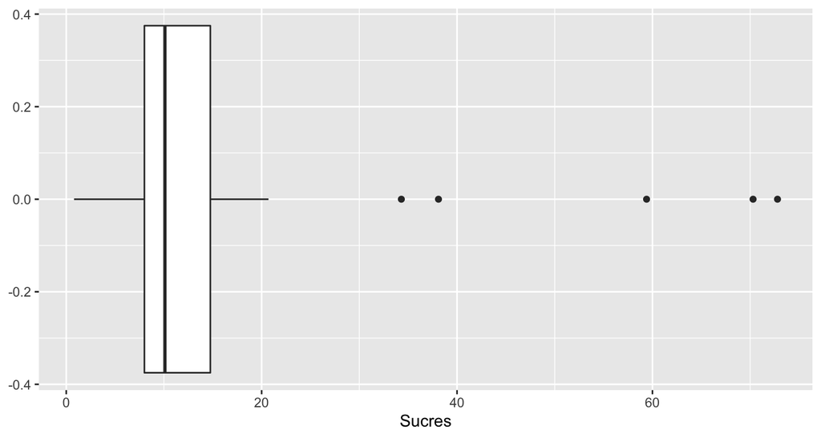

```r
ggplot(data=fruits, aes(x = Sucres)) +
  geom_boxplot()
```

## Boxplot : lien entre une variable catégorielle et une variable continue

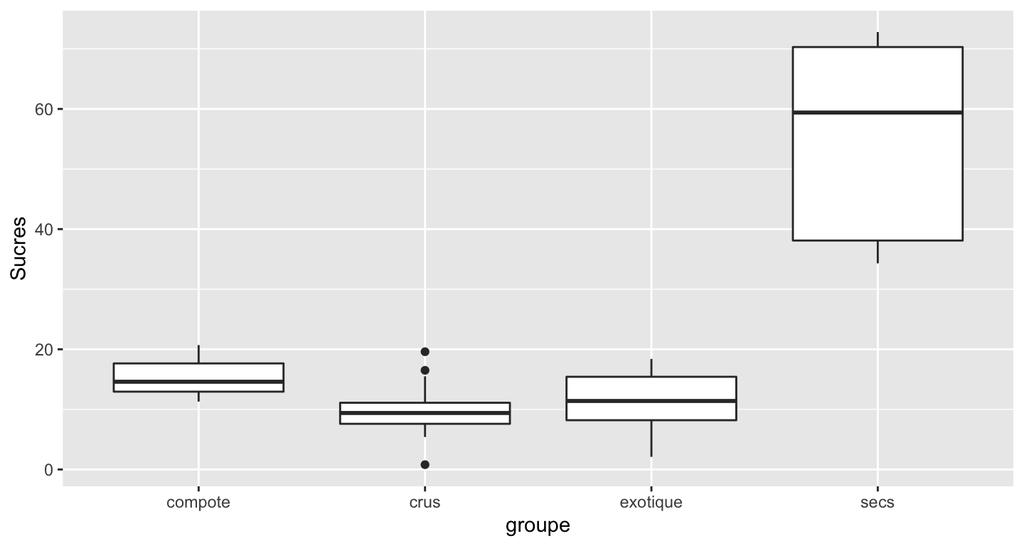

```r
ggplot(data=fruits, aes(x=groupe, y=Sucres)) +
  geom_boxplot()
```

## Avec des violons

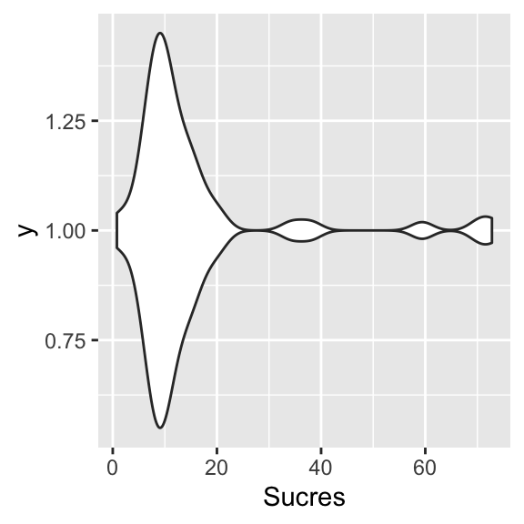

```r
ggplot(data=fruits,
       aes(x = Sucres, y = 1)) +
  geom_violin()
```

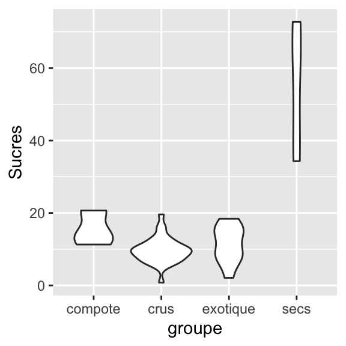

```r
ggplot(data=fruits,
       aes(x = groupe, y = Sucres)) +
  geom_violin()
```

## A vous !

Complétez le code suivant pour obtenir la figure de droite :

```r
ggplot(fruits,
       aes(x = Fibres > 1.5,
           y = Proteines,
           fill = ***)) +
  geom_***()
```

[figure not shown]

## Personnalisation

## Thèmes

Les *thèmes* sont des fonctions qui permettent de modifier certains paramètres graphiques comme :

- la couleur du fond,
- la couleur des axes,
- la couleur des grilles majeures et mineures,
- etc.

Exemple de fonctions thèmes (`theme_***()`) :

- `theme_bw()` : pour un thème en noir et blanc,
- `theme_minimal()` : pour un thème minimaliste,
- `theme_void()` : pour un thème dépouillé

## Exemple sur un histogramme : `theme_bw()`

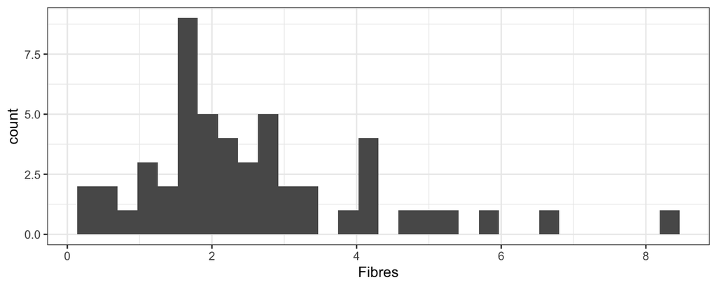

```r
ggplot(fruits, aes(Fibres)) +
  geom_histogram() +
  theme_bw()
```

## Exemple sur un histogramme : `theme_minimal()`

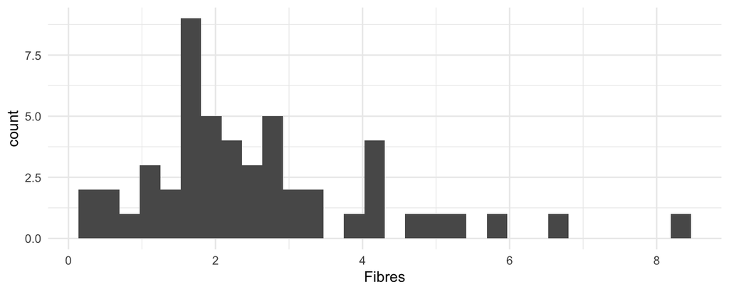

```r
ggplot(fruits, aes(Fibres)) +
  geom_histogram() +
  theme_minimal()
```

## Exemple sur un histogramme : `theme_void()`

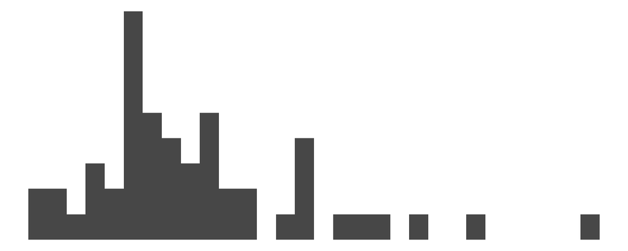

```r
ggplot(fruits, aes(Fibres)) +
  geom_histogram() +
  theme_void()
```

## A vous !

1. Consultez la page d’aide de la fonction `theme_bw` avec la commande `?theme_bw`
2. Choisissez la thème permettant de réaiser le graphe à droite en complétant la commande suivante.

```r
ggplot(fruits, aes(y = Fibres)) +
  geom_boxplot() +
  theme_***()
```

[figure not shown]

## Autres personnalisations “simples”

- **Titre** : avec la fonction `ggtitle`
- **Titre de l’axe des \(x\)** : avec la fonction `xlab`
- **Titre de l’axe des \(y\)** : avec la fonction `ylab`

Mais je vous conseille d’utiliser la fonction `labs` qui permet de faire tout cela, et plus !

```r
labs(
  title = "Titre du graphe",
  subtitle = "Sous-titre du graphe",
  x = "Titre de l'axe des x",
  y = "Titre de l'axe des y",
  color = "Titre de la légende des couleurs",
  shape = "Titre de la légende des formes"
)
```

## Personnalisations avancées

Avec la fonction `theme()`, qui a une syntaxe bien particulière : chaque élément doit être spécifié selon sa nature.

- Pour changer la taille, la police, la couleur d’élément de type “texte”, on utilise `element_text(size=, colour = "", family = "")`
- Pour changer la couleur et la taille d’une ligne, on utilise `element_line(colour=“”, size=)`
- Pour personnaliser la couleur du fond, on utilise `element_rect(fill = "")`

## Ce que l’on peut changer avec `theme()`

- `axis.title`, `axis.title.x`, `axis.title.y` : taille, police, couleur, …
- `axis.text`, `axis.text.x`, `axis.text.y` : taille, police, couleur, …
- `axis.ticks`, `axis.ticks.x`, `axis.ticks.y`
- `axis.line`, `axis.line.x`, `axis.line.y`
- `panel.background` : couleur
- `panel.grid.major`, `panel.grid.minor` : couleur, taille
- `legend.text`: taille, police, couleur
- `legend.position`
- `plot.title` : taille, police, couleur

## Nuages de points

## Avec `geom_point`

Cette géométrie nécessite des paramètres esthétiques de position (en \(x\) et \(y\)), et accepte optionnellement des paramètres esthétiques de taille, couleur et forme.

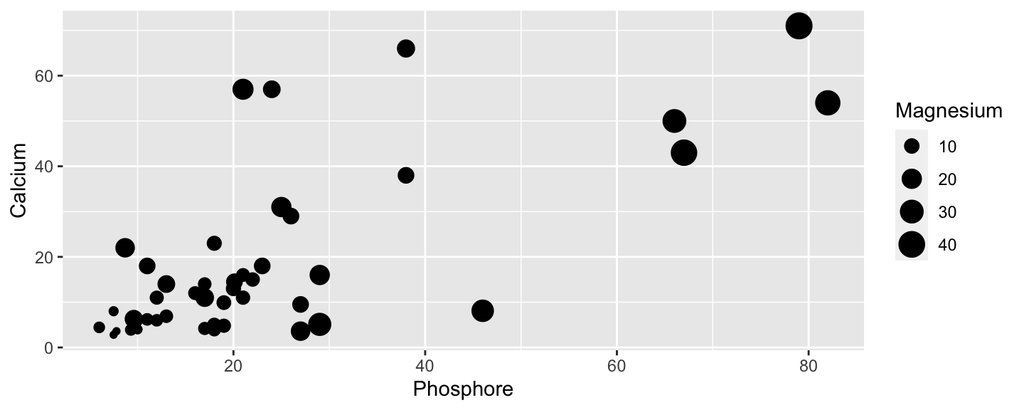

```r
ggplot(fruits, aes(x = Phosphore, y = Calcium, size = Magnesium)) +
  geom_point()
```

## Paramètres esthétiques

Lorsqu’ils sont spécifiés dans la fonction `aes()`, ces paramètres appliquent les valeurs d’une variable à une caractéristique des objets graphiques tracés par les géométries.

- `color` ou `colour` : couleur du point
- `fill` : couleur de remplissage
- `size` : taille
- `shape` : forme
- `alpha` : transparence
- `linetype` : type de ligne
- `label` : étiquettes

Lorsqu’ils sont appliqués en dehors de la fonction `aes()`, leur comportement est plus général !

## Exemple

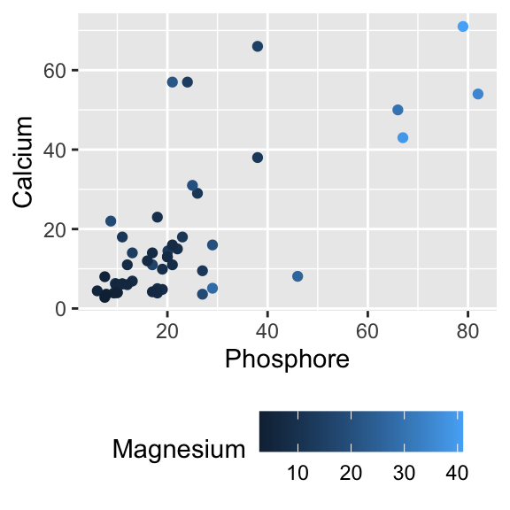

```r
ggplot(fruits,
       aes(x = Phosphore, y = Calcium,
           color = Magnesium)) +
  geom_point() +
  theme(legend.position = "bottom")
```

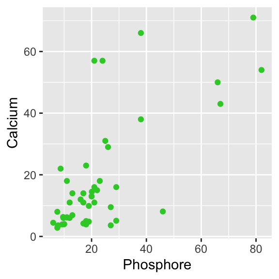

```r
ggplot(fruits,
    aes(x = Phosphore, y = Calcium)) +
  geom_point(color = "limegreen")
```

## A vous !

Complétez la commande suivante pour obtenir le graphe ci-contre.

```r
ggplot(fruits,
       aes(x = Sucres,
           y = Proteines,
           *** = Magnesium,
           *** = ***)) +
  geom_***() +
  ***(title = "Fruits",
     x = "Sucres (g/100 g)",
     y = "Protéines, N x 6.25 (g/100 g)",
     size = "Magnésium\n(mg/100 g)",
     ***= "Groupe") +
  theme_***()
```

[figure not shown]

## Au secours, mes points se superposent!

Pas de panique, on peut utiliser la transparence (aka `alpha`) :

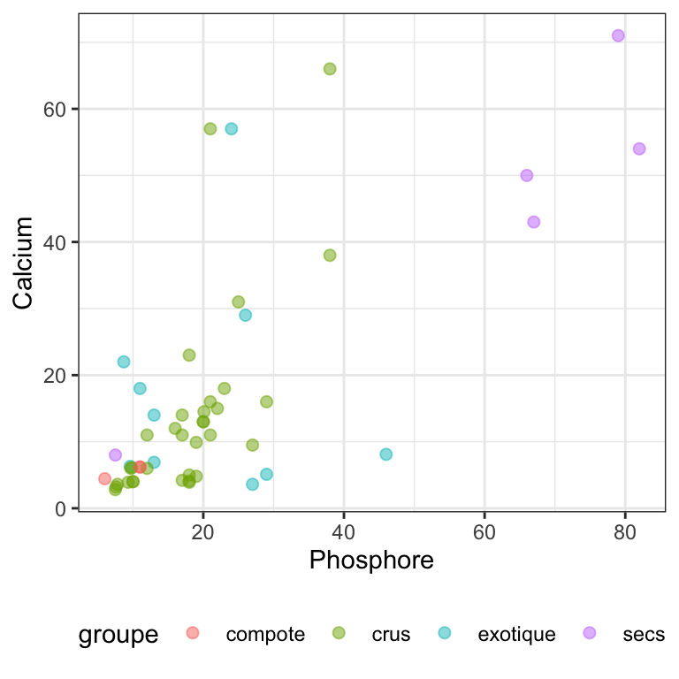

```r
ggplot(fruits,
       aes(x = Phosphore,
           y = Calcium,
           color = groupe)) +
  geom_point(alpha = 0.5,
             size = 2) +
  theme_bw() +
  theme(legend.position =
          "bottom")
```

## Changer les échelles

## Avec les fonctions `scale_***`

Ces fonctions vont vous permettre de personnaliser l’échelle, en \(x\), en \(y\), mais pas seulement ! Ce concept est généraliser dans `ggplot2` à de nombreux paramètres esthétiques. Par exemple :

## A vous !

Complétez la commande suivante pour obtenir le graphe ci-contre.

```r
ggplot(fruits,
       aes(Phosphore,
           Calcium)) +
  geom_point(*** = "white") +
  scale_***() +
  scale_***() +
  labs(x = "log10(Phosphore)",
       y = "log10(Calcium)") +
  theme_dark()
```

[figure not shown]

## Avec les fonctions `coord_***`

Pour modifier le système de coordonnées **après** avoir appliquer toutes les transformations spécifiées auparavant (par une fonction `scale_***` par exemple). Par exemple :

- `coord_fixed` pour fixer le ratio des unités de l’axe des \(y\) sur les unités de l’axe des \(x\),
- `coord_equal` quand ce ratio vaut 1,
- `coord_flip` pour échanger les axes,
- `coord_polar` pour passer d’un système de coordonnées cartésien à un système de coordonnées polaires

## Pour s’amuser !

Transformez les coordonnées du graphe suivant en coordonnées polaires (`coord_polar(theta = "y")`). Quel est le résultat ?

```r
ggplot(fruits, aes(x = 1, fill = groupe)) +
  geom_bar(width = 1) +
  theme_void()
```

## Avec les fonctions `*lim*`

Change le minimum et le maximum d’un axe. Attention, toutes les valeurs en dehors des nouveaux axes sont **éliminées** !

- `xlim`, `ylim` ou `lims` pour spécifier l’étendue,
- `expand_limits` pour *étendre* l’étendue à certaines valeurs.

Pour faire un “zoom” sans perdre de points, il faut utiliser la fonction `coord_cartesian` ou une fonction du type `scale_***`

## Créer des “facettes”

## La fonction `facet_wrap`

S’uilise pour diviser le graphe en panneaux selon les modalités d’une variable catégorielle.

Attention à la syntaxe : elle est basée sur l’utilisation du terme `vars`, qui permet d’accéder aux variables du jeu de données spécifié.

Par exemple, pour diviser le graphe `g` en plusieurs panneaux selon les modalités d’un facteur `fac`, on écrira

```
g + facet_wrap(facets = vars(fac))
```

On peut également utiliser une “formule” :

```
g + facet_wrap(~ fac)
```

## Exemple

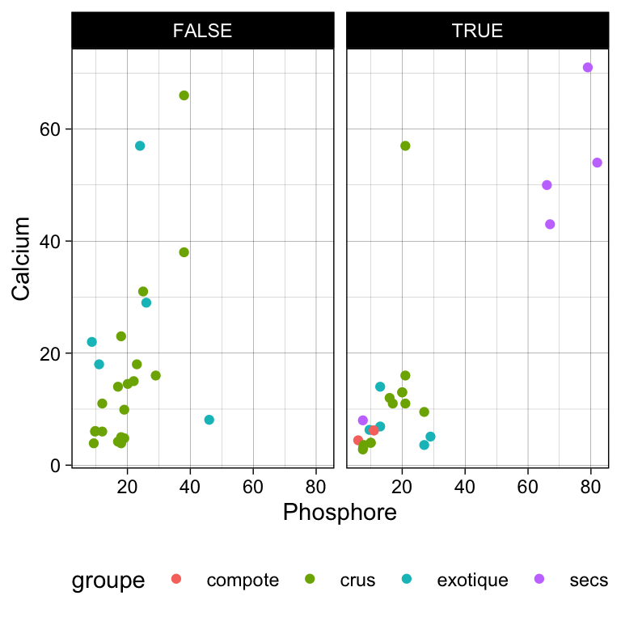

```r
ggplot(fruits,
       aes(x = Phosphore,
           y = Calcium,
           color = groupe)) +
  geom_point() +
  facet_wrap(vars(Sucres > 10)) +
  theme_bw() +
  theme(legend.position =
          "bottom")
```

## Avec la fonction `facet_grid`

S’utilise de la même façon que `facet_wrap`.

Par exemple, pour diviser le graphe `g` en plusieurs panneaux selon les modalités d’un facteur `factorow` pour les lignes et `factocol` pour les colonnes, on écrira

```
g + facet_grid(rows = vars(factorow), cols = vars(factocol))
```

On peut aussi utiliser une formule :

```
g + facet_grid(factorow ~ factocol)
```

CONSEIL : pour l’utilisation de facettes, faites attention à bien nommer les modalités de vos facteurs pour rendre le graphe plus clair.

## Sauvegarder un graphe

## Méthode conseillée : avec ggsave

Fonctionnement et exemple :

```
g <- ggplot(fruits, aes(groupe)) + geom_bar()
ggsave(filename = "mongraphe.png", plot = g)
```

L’extension donnée dans `filename` sera magiquement détectée pour sauvegarder le fichier au bon format !

## Conclusion

## En quelques mots

Nous avons vu un package de représentations graphiques très puissant ! `ggplot2` fonctionne sur la base d’un canevas, de paramètres esthétiques comme la position en \(x\), en \(y\), les couleurs, la forme etc. A partir de ces paramètres, on va tracer les graphes à l’aides de *géométries*, qui peuvent se superposer !

## Quelques remarques

1. `ggplot2` est très complet… et très complexe
2. Il faut prendre son temps, et savoir travailler avec ses petits jeux de données préférés bien connus et **très très très très propres** pour travailler sur son graphe,
3. Personnaliser un graphe prend du temps, il faut s’armer de patience…

## [N’oubliez pas la feuille de triche !](https://www.rstudio.com/wp-content/uploads/2015/03/ggplot2-cheatsheet.pdf)

[figure not shown]